# Homework 1

Author

Gayatri Chintala

Professional wrestling, while not everyone’s cup of tea, is big business. What started as a carnival act has turned into a global entertainment industry. Netflix recently announced a long-term streaming partnership with the biggest North American wrestling company, WWE – this deal is reportedly worth $5 billion. Like any large entity, WWE is not without competition, drama, and scandal.

## Step 1

In the `calls` folder, you’ll find 3 text files – these are transcripts from recent quarterly earnings calls. Read those files in, with appropriate column names for ticker, quarter, and year columns. Perform any data cleaning that you find necessary.

```r
library(dplyr)
library(tidytext)

my_files <- function(file_location, ticker, quarter, year, sep = "\n") {
  file_content <- readLines(file_location)
  file_content <- c(file_content, "")

  data.frame(value = file_content, stringsAsFactors = FALSE) %>%
    filter(nchar(trimws(value)) > 0) %>%
    mutate(ticker = ticker,
           quarter = quarter,
           year = year) %>%
    setNames(c("Participants", "ticker", "quarter", "year"))
}

wwe_1 <- my_files("C:/Users/Gayatri Chintala/Documents/Unstructured Data/calls/wwe_q1_2023.txt", "WWE", "Q1", 2023)
wwe_1 <- wwe_1[-1, ]
wwe_2 <- my_files("C:/Users/Gayatri Chintala/Documents/Unstructured Data/calls/wwe_q2_2023.txt", "WWE", "Q2", 2023)
wwe_2 <- wwe_2[-1, ]
wwe_3 <- my_files("C:/Users/Gayatri Chintala//Documents/Unstructured Data/calls/edr_q3_2023.txt", "WWE", "Q3", 2023)
wwe_3 <- wwe_3[-1, ]

wwe <- bind_rows(wwe_1,wwe_2,wwe_3)

wwe <- wwe[!grepl("Conference Call Participants|Operator", wwe$Participants), ]
```

## Step 2

Use the AlphaVantage api to get daily stock prices for WWE and related tickers going back 5 years. You cannot use any AlphaVantage packages. Tell me about the general trend that you are seeing. Has recent news impacted the stock price?

```r
#AlphVantage API KEY: AD0KR31D8L4N0J43


library(dplyr)
library(rvest)
library(httr)
library(tibble)

av_key <- "AD0KR31D8L4N0J43"


av_link <- glue::glue("https://www.alphavantage.co/query?function=TIME_SERIES_DAILY&symbol=WWE&outputsize=full&apikey={av_key}")


av_response <- httr::GET(av_link)
av_read <- httr::content(av_response, "parsed", simplifyVector = TRUE)

av_series <- av_read$`Time Series (Daily)`
av_dates <- names(av_series)

library(purrr)

av_data <- map_dfr(av_series, bind_rows) %>%
  mutate(date = av_dates)

av_data <- av_data %>%
  mutate_at(vars(-date), as.numeric) %>%
  mutate(date = as.Date(date))

av_data <- av_data %>% filter(date >= Sys.Date() - 365 * 5)

av_data <- av_data %>% arrange(date)



av_link2 <- glue::glue("https://www.alphavantage.co/query?function=TIME_SERIES_DAILY&symbol=TKO&outputsize=full&apikey={av_key}")


av_response2 <- httr::GET(av_link2)
av_read2 <- httr::content(av_response2, "parsed", simplifyVector = TRUE)

av_series2 <- av_read2$`Time Series (Daily)`
av_dates2 <- names(av_series2)

library(purrr)

av_data2 <- map_dfr(av_series2, bind_rows) %>%
  mutate(date = av_dates2)

av_data2 <- av_data2 %>%
  mutate_at(vars(-date), as.numeric) %>%
  mutate(date = as.Date(date))

av_data2 <- av_data2 %>% filter(date >= Sys.Date() - 365 * 5)

av_data2 <- av_data2 %>% arrange(date)

new_data <- rbind(av_data, av_data2)

new_data
```

```
# A tibble: 1,258 × 6
   `1. open` `2. high` `3. low` `4. close` `5. volume` date
       <dbl>     <dbl>    <dbl>      <dbl>       <dbl> <date>
 1      82.4      86.0     82.4       85.8     1086972 2019-02-08
 2      86.2      87.9     86.0       86.8     1023175 2019-02-11
 3      87.6      89.1     86.8       87.2     1024699 2019-02-12
 4      87.7      89.6     87.0       88.2     1207211 2019-02-13
 5      88.1      89.5     87.4       88.9      695733 2019-02-14
 6      89.2      89.2     86.2       87.5      864119 2019-02-15
 7      87.0      87.6     86.3       86.6      549412 2019-02-19
 8      86.3      88.2     85.7       86.3      783272 2019-02-20
 9      86.1      86.9     85.6       86.5      358764 2019-02-21
10      86.8      87.0     85.6       86.5      486274 2019-02-22
# ℹ 1,248 more rows
```

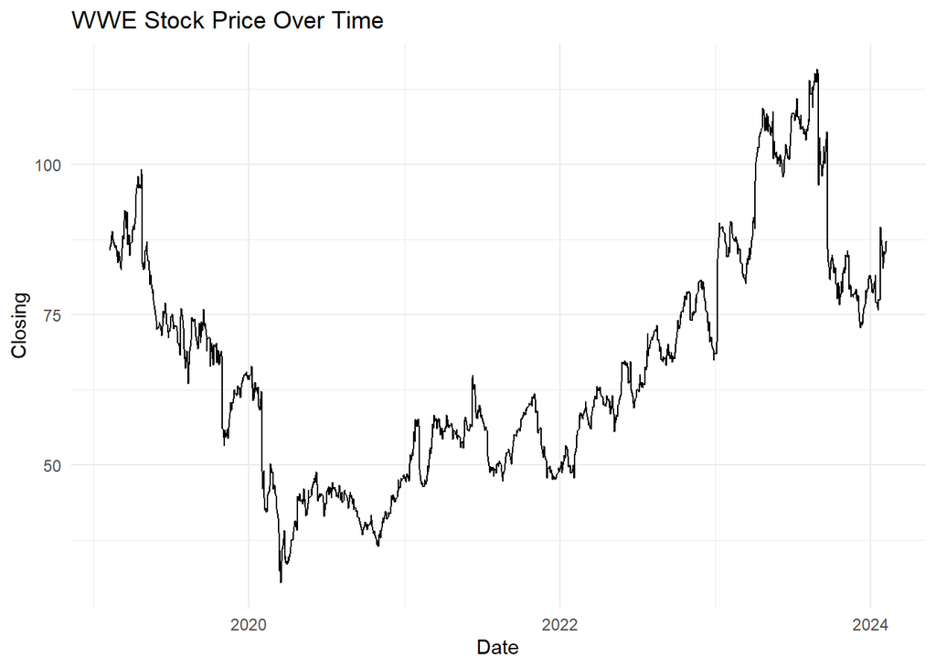

```r
library(ggplot2)

ggplot(new_data, aes(x = date, y = `4. close`)) +
  geom_line() +
  labs(title = "WWE Stock Price Over Time",
       x = "Date",
       y = "Closing") +
  theme_minimal()
```

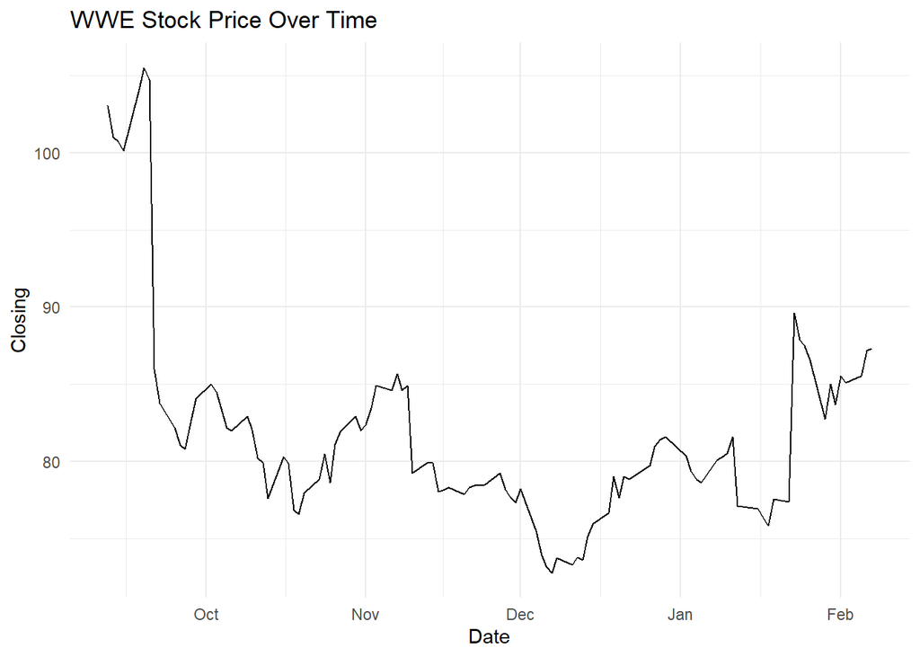

```r
#I can see it is dropping, but I wanted something precise, so I checked the situation after September, when the merge happened.

TKO_dates <- new_data %>% filter(date >= as.Date("2023-09-12"))

ggplot(TKO_dates, aes(x = date, y = `4. close`)) +
  geom_line() +
  labs(title = "WWE Stock Price Over Time",
       x = "Date",
       y = "Closing") +
  theme_minimal()
```

## Step 3

Just like every other nerdy hobby, professional wrestling draws dedicated fans. Wrestling fans often go to cagematch.net to leave reviews for matches, shows, and wrestlers. The following link contains the top 100 matches on cagematch: https://www.cagematch.net/?id=111&view=statistics

Please note that if you are using R, you will need to wrap the link the the `url` function before reading it.

```r
library(rvest)

library(magrittr)
library(stringr)
library(dplyr)
library(xml2)

my_link <- url("https://www.cagematch.net/?id=111&view=statistics")

my_table <- read_html(my_link) %>%
  html_table(header = TRUE) %>%
  `[[`(1)

stars_to_numeric <- function(stars) {
  if (grepl("\\*", stars)) {
    stars_count <- str_count(stars, "\\*")
    if (grepl("1/4", stars)) {
      return(stars_count + 0.25)
    } else if (grepl("3/4", stars)) {
      return(stars_count + 0.75)
    } else if (grepl("1/2", stars)) {
      return(stars_count + 0.50)
    }  else {
      return(stars_count)
    }
  } else {
    return(0)
  }
}

my_table$WON <- sapply(my_table$WON, stars_to_numeric)
```

```r
library(rvest)
library(dplyr)
library(httr)
library(xml2)

my_link <- url("https://www.cagematch.net/?id=111&view=statistics")

promotion <- read_html(my_link) %>%
  html_elements(".ImagePromotionLogoMini") %>%
  html_attr("title")

my_table <- cbind(my_table, promotion)

my_table <- my_table[, -3]
```

*What is the correlation between the WON rating and cagematch rating?

```r
correlation <- cor(my_table$WON, my_table$Rating)
print(correlation)
```

```
[1] 0.3202547
```

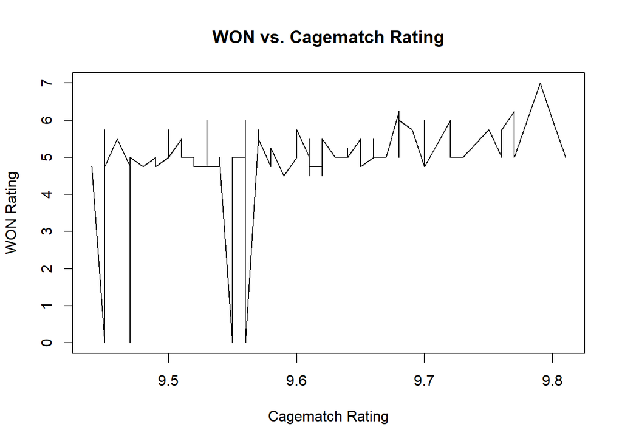

```r
plot(my_table$Rating, my_table$WON, main = "WON vs. Cagematch Rating", xlab = "Cagematch Rating", ylab = "WON Rating", type = "l")
```

** Which wrestler has the most matches in the top 100?

```r
#I need to count which wrestler played the most matches using group by
most_matches <- my_table %>%
                group_by(`Match fixture`) %>%
                summarise(count = n()) %>%
                arrange(desc(count))

individual_names <- strsplit(most_matches$`Match fixture`, "\\s*vs\\.\\s*|\\s*&\\s*|\\s*,\\s*") %>%
                             unlist()

#I need to get the highest frequency of the most occuring
# most_common <- frequency(individual_names)
top_wrestler <- table(individual_names)

most_frequent_name <- names(top_wrestler)[which.max(top_wrestler)]
print(most_frequent_name)
```

```
[1] "Kenta Kobashi"
```

*** Which promotion has the most matches in the top 100?

```r
highest_promotion <- which.max(my_table$Votes)
promotion_name <- my_table$promotion[highest_promotion]
print(promotion_name)
```

```
[1] "New Japan Pro Wrestling"
```

**** What is each promotion’s average WON rating?

```r
avg_promo_WON_rating <- avg_won <- my_table %>%
                        group_by(promotion) %>%
                        summarise(avg_won = mean(WON, na.rm = TRUE)) %>%
                        arrange(desc(avg_won))
print(avg_promo_WON_rating)
```

```
# A tibble: 14 × 2
   promotion                            avg_won
   <chr>                                  <dbl>
 1 All Elite Wrestling                     5.5
 2 New Japan Pro Wrestling                 5.31
 3 All Japan Pro Wrestling                 5.04
 4 Japanese Women Pro-Wrestling Project    5
 5 Total Nonstop Action Wrestling          5
 6 World Championship Wrestling            5
 7 All Japan Women's Pro-Wrestling         4.88
 8 World Wrestling Entertainment           4.88
 9 Pro Wrestling NOAH                      4.79
10 JTO                                     4.75
11 Ring Of Honor                           4.31
12 DDT Pro Wrestling                       0
13 Lucha Underground                       0
14 Pro Wrestling Guerrilla                 0
```

***** Select any single match and get the comments and ratings for that match into a data frame.

```r
library(rvest)
library(dplyr)
library(stringr)

link <- url("https://www.cagematch.net/?id=111&nr=9450&page=99")

my_page <- read_html(link) %>%
  html_elements(".CommentContents") %>%
  html_text()


comments <- data.frame(my_page)
names(comments) <- "Comments"
comments$Ratings <- my_page


comments$Ratings <- str_extract(comments$Ratings, "\\d+\\.\\d+")

comments$Comments <- gsub("\\[\\d+\\.\\d+\\]\\s*", "", comments$Comments)
```

## Step 4

You can’t have matches without wrestlers. The following link contains the top 100 wrestlers, according to cagematch: https://www.cagematch.net/?id=2&view=statistics

```r
cagematch_link <- url("https://www.cagematch.net/?id=2&view=statistics")
```

```r
library(rvest)
library(dplyr)
library(stringr)

main_link <- url("https://www.cagematch.net/?id=2&view=statistics")
content <- read_html(main_link)%>%
           html_elements("a[href*='?id=2&nr=']") %>%
           html_attr("href") %>%
           paste0("https://www.cagematch.net", .)

modified_content <- gsub("gimmick=.*", "page=22", content)

match_stats <- function(content) {
  my_page <- read_html(url(content)) %>%
    html_elements(".InformationBoxContents") %>%
    html_text()

  return(my_page)
}

statistics <- data.frame()

for (i in 1:length(modified_content)) {
  row_values <- gsub("\\D+", " ", match_stats(modified_content[i]))
  statistics <- rbind(statistics, as.character(unlist(strsplit(row_values, " "))))
}
statistics <- statistics[, -c(3, 4, 6, 7, 9, 10)]
colnames(statistics) <- c("Matches", "Wins", "Losses" , "Draws")

library(magrittr)

players_link <- url("https://www.cagematch.net/?id=2&view=statistics")

players_table <- read_html(players_link) %>%
  html_table(header = TRUE) %>%
  `[[`(1)

statistics <- cbind(statistics, players_table$Gimmick)
colnames(statistics) <- c("Matches", "Wins", "Losses" , "Draws", "Names")

statistics$Matches <- as.numeric(statistics$Matches)
statistics$Wins <- as.numeric(statistics$Wins)
statistics$Losses <- as.numeric(statistics$Losses)
statistics$Draws <- as.numeric(statistics$Draws)
```

*** Of the top 100, who has wrestled the most matches?

```r
most_matches <- which.max(statistics$Matches)
player_name <- statistics$Names[most_matches]
print(player_name)
```

```
[1] "Ric Flair"
```

***** Of the top 100, which wrestler has the best win/loss?

```r
best_win_loss_ratio <- ifelse (statistics$Wins > 0 & statistics$Losses > 0, statistics$Wins / statistics$Losses, 0)

player_name <- statistics$Names[which.max(best_win_loss_ratio)]

print(player_name)
```

```
[1] "Lou Thesz"
```

## Step 5

With all of this work out of the way, we can start getting down to strategy.

–First, what talent should WWE pursue?

After thoroughly examining the data and considering various factors, my recommendation for WWE’s pursuit falls on Lou Thesz. My choice is rooted in his remarkable win/loss ratio, which stands out as the best among the candidates.

While Ric Flair boasts an impressive record of having wrestled the most matches, the competitive and lucrative nature of WWE demands not only experience but also a history of victories. In this regard, Lou Thesz’s superior win/loss ratio positions him as a more compelling choice.

On the other hand, Kenta Kobashi may have participated in numerous matches, but success in WWE is not solely about quantity. Quality, specifically in terms of victories against formidable opponents, is paramount. Simply engaging in a multitude of matches does not carry as much weight unless it translates into significant triumphs.

In conclusion, Lou Thesz emerges as the candidate who not only brings a stellar win/loss ratio to the table but also embodies the winning spirit that aligns with WWE’s competitive and performance-driven ethos.

#LousThezForTheWin!!

–Second, reconcile what you found in steps 3 and 4 with Netflix’s relationship with WWE. Use the data from the following page to help make your case: https://wrestlenomics.com/tv-ratings/

The data paints a clear picture of WWE’s ratings experiencing a decline over the years, with exceptions for standout shows like WWE SMACKDOWN and WWE RAW. It’s evident that WWE needs to navigate through some changes to sustain its viewership.

The insights gained from steps 3 and 4 provide a valuable roadmap for WWE’s strategic adjustments. A significant focus should be directed towards wrestlers with the most matches in the top 100 and those boasting the best win/loss ratios. This approach not only preserves the existing fan base but also serves as a potential magnet for new viewers.

The fervent comments in the section underscore the passion fans have for the sport. Their loyalty and enthusiasm towards specific players present a key element that WWE can leverage to bolster its appeal.

Delving into the promotions, New Japan Pro Wrestling emerges with the most matches in the top 100, securing a solid second place in the WON rating. This presents a compelling benchmark for WWE to consider in refining its approach.

In essence, these details not only guide WWE in retaining fan interest but also offer a nuanced understanding of the interconnected dynamics that influence ratings. By leveraging these insights, WWE can recalibrate its strategy to align with the evolving landscape of professional wrestling.

–Third, do you have any further recommendations for WWE?

Beyond the insights discussed earlier, my recommendation for WWE would be to place a paramount focus on its fans. This sport thrives on passion, and the patterns we’ve observed so far only reinforce that sentiment. It’s crucial for WWE to continually explore new ways and adapt to changing times, ensuring fans remain captivated and invested, thereby sustaining the financial flow.

When venturing into new platforms, WWE should carefully consider its existing viewership. Changes may not always resonate well with fans, so a mindful approach is essential.

In essence, my suggestion for WWE is a simple yet profound one – always keep the audience at the forefront. In a passion-driven sport like this, there’s no substitute for a satisfied customer. This principle will undoubtedly serve as a guiding light in navigating the ever-evolving landscape of entertainment.